# dream: Differential expression testing with linear mixed models for repeated measures

[Gabriel E Hoffman](http://gabrielhoffman.github.io)

06/21/2018

Abstract

**D**ifferential expression for **re**pe**a**ted **m**easures (dream) uses a linear model model to increase power and decrease false positives for RNA-seq datasets with multiple measurements per individual. Dream fits seamlessly into the widely used workflow of limma/voom (Law et al. 2014).  
variancePartition v1.11.5.1

### Description

Dream uses a linear model model to increase power and decrease false positives for RNA-seq datasets with repeated measurements. Dream achieves this by combining multiple statistical concepts into a single statistical model. The dream model includes:

| Model property | Package | Reference |
| --- | --- | --- |
| precision weights to model measurement error in RNA-seq counts | limma/voom | Law et al. (2014) |
| ability to model multiple random effects | lme4 | Bates et al. (2015) |
| random effects estimated separately for each gene | variancePartition | Hoffman and Schadt (2016) |
| hypothesis testing for fixed effects in linear mixed models | lmerTest | Kuznetsova, et al. (2017) |
| small sample size hypothesis test | pbkrtest | Halekoh, et al. (2014) |
| emprical Bayes moderated t-test | limma/eBayes | Smyth (2004) |

Dream also includes multi-threaded analysis across thousands of genes on a multi-core machine.

### Usage

Process raw count data using limma/voom.

```r
library(variancePartition)
library(edgeR)
library(doParallel)
data(varPartDEdata)

isexpr = rowSums(cpm(countMatrix)>0.1) >= 3

# Standard usage of limma/voom
genes = DGEList( countMatrix )
genes = calcNormFactors( genes )
design = model.matrix( ~ Disease, metadata)
vobj_tmp = voom( genes, design, plot=FALSE)

# apply duplicateCorrelation
dupcor <- duplicateCorrelation(vobj_tmp,design,block=metadata$Individual)

# run voom considering the duplicateCorrelation results
# in order to compute more accurate precision weights
# Otherwise, use the results from the first voom run
vobj = voom( genes, design, plot=FALSE, block=metadata$Individual, correlation=dupcor$consensus)
```

Limma has a built-in approach for analyzing repeated measures data using duplicateCorrelation. The model can handle a single random effect, and forces the magnitude of the random effect to be the same across all genes.

```r
design = model.matrix( ~ Disease, metadata)

# Estimate linear mixed model with a single variance component
# Fit the model for each gene,
dupcor <- duplicateCorrelation(vobj, design, block=metadata$Individual)

# But this step uses only the genome-wide average for the random effect
fitDupCor <- lmFit(vobj, design, block=metadata$Individual, correlation=dupcor$consensus)

# Fit Empirical Bayes for moderated t-statistics
fitDupCor <- eBayes( fitDupCor )
```

The dream model operates directly on the results of voom. The only change compared to the standard limma workflow is to replace lmFit with dream.

```r
cl <- makeCluster(4)
registerDoParallel(cl)

# Specify formula with at least one random effect
# The variable to be tested should be a fixed effect
form <- ~ Disease + (1|Individual)

# Get the contract matrix for the hypothesis test
L = getContrast( vobj, form, metadata, "Disease1")

# Fit the dream model on each gene
# Apply the contrast matrix L for the hypothesis test
# By default, uses the Satterthwaite approximation for the hypothesis test
# for this test, just run on first 10 genes
fitmm = dream( vobj, form, metadata, L)
```

```
## Projected run time: ~ 8 min
```

```r
# Fit Empirical Bayes for moderated t-statistics
fitmm_eb = eBayes( fitmm )

# get results
topTable( fitmm_eb )
```

```
##                                    logFC  AveExpr        t      P.Value
## ENST00000283033.5 gene=TXNDC11  1.555819 3.567624 38.95624 6.095513e-23
## ENST00000257181.9 gene=PRPF38A  1.382756 4.398270 27.97231 1.294100e-19
## ENST00000525790.1 gene=TDRKH    1.496308 3.184931 21.74513 3.993169e-17
## ENST00000264485.5 gene=SLC4A4   1.415366 4.476664 21.06019 8.205862e-17
## ENST00000421974.2 gene=ATP6V0E2 1.372569 3.478030 21.05959 8.211084e-17
## ENST00000373277.4 gene=SH2D3C   1.383826 3.509569 20.86909 1.007023e-16
## ENST00000295633.3 gene=FSTL1    1.387415 4.625435 20.11317 2.301915e-16
## ENST00000339861.4 gene=SEMA4D   1.396601 4.186466 19.27068 5.980852e-16
## ENST00000231454.1 gene=IL5      1.493454 1.789759 18.88681 9.355289e-16
## ENST00000577031.1 gene=PAM16    1.460190 1.137609 18.72485 1.132607e-15
##                                    adj.P.Val        B
## ENST00000283033.5 gene=TXNDC11  1.180335e-18 37.34041
## ENST00000257181.9 gene=PRPF38A  1.252947e-15 32.37189
## ENST00000525790.1 gene=TDRKH    2.577457e-13 27.93311
## ENST00000264485.5 gene=SLC4A4   3.179989e-13 27.33875
## ENST00000421974.2 gene=ATP6V0E2 3.179989e-13 27.33822
## ENST00000373277.4 gene=SH2D3C   3.250000e-13 27.16847
## ENST00000295633.3 gene=FSTL1    6.367756e-13 26.47500
## ENST00000339861.4 gene=SEMA4D   1.447665e-12 25.66286
## ENST00000231454.1 gene=IL5      2.012842e-12 25.27836
## ENST00000577031.1 gene=PAM16    2.193180e-12 25.11331
```

You can also perform a hypothesis test between two levels

```r
form <- ~ 0 + Disease + (1|Individual)
L = getContrast( vobj, form, metadata, c("Disease1", "Disease0"))
```

#### Small-sample method

For small datasets, the Kenward-Roger method can be more powerful. But it is **substantially** more computationally intensive.

```r
fitmmKR = dream( vobj[1:10,], form, metadata, L, ddf="Kenward-Roger")
```

```
## Projected run time: ~ 0.02 min
```

## variancePartition plot

```r
form = ~ (1|Individual) + (1|Disease)
vp = fitExtractVarPartModel( vobj, form, metadata)
```

```
## Projected run time: ~ 173 min
```

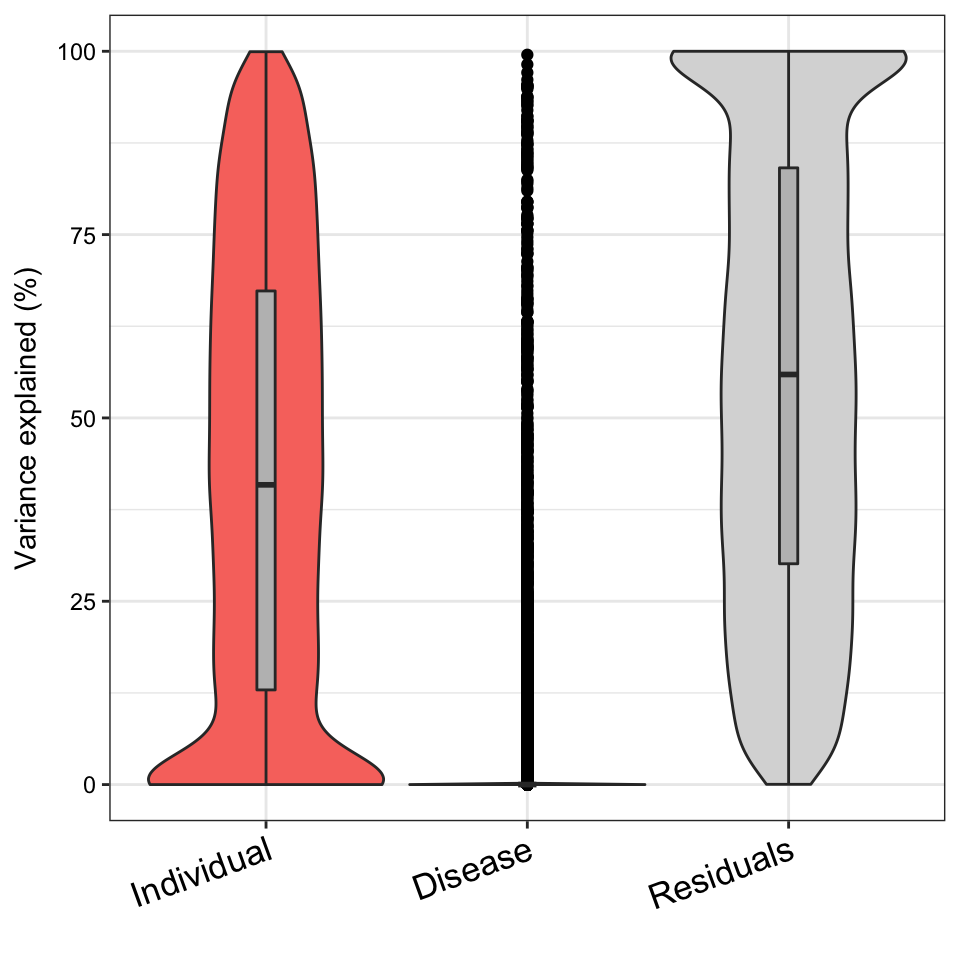

```r
plotVarPart( sortCols(vp))
```

## Compare p-values from dream and duplicateCorrelation

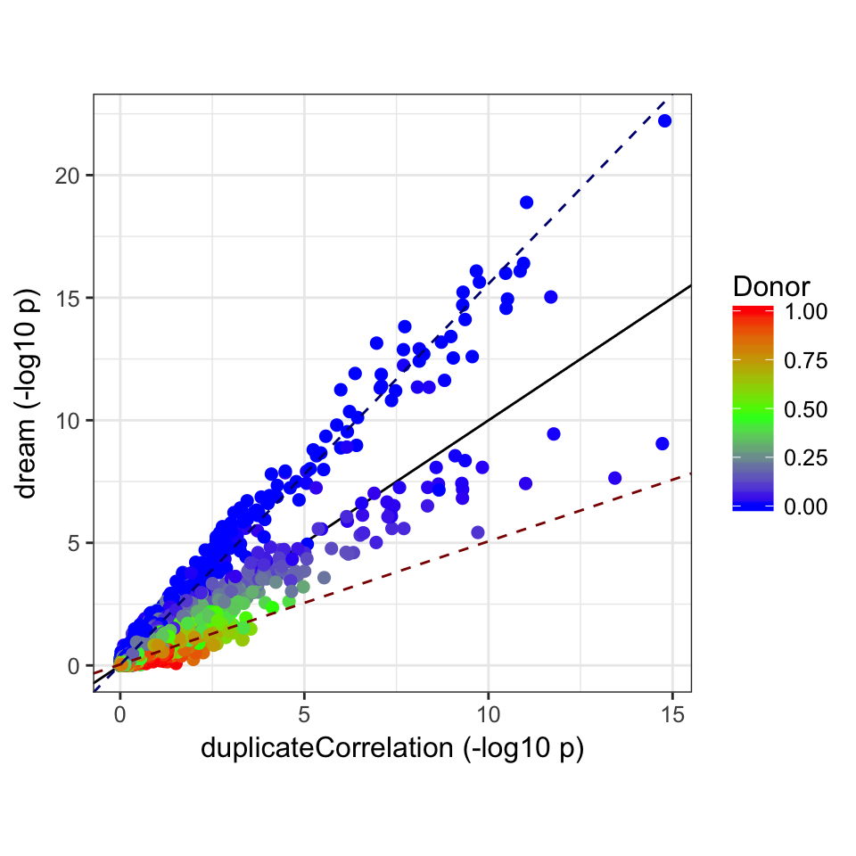

```r
plotCompare = function( stat1, stat2, vpDonor, dupcorvalue, N=3000){
  library(scales)

  df2 = data.frame(dupCor=-log10(stat1), dream=-log10(stat2), vpDonor=vpDonor, delta = vpDonor - dupcorvalue)

  c1 = sort(df2$delta)[N]
  c2 = sort(df2$delta)[length(df2$delta) - N]

  l1 = lm(dream ~ dupCor, df2[df2$delta >= c2,])
  l2 = lm(dream ~ dupCor, df2[df2$delta <= c1,])

  df_line = data.frame(rbind(coef(l1), coef(l2)))
  colnames(df_line) = c('a', 'b')
  df_line$type = c('darkred', 'navy')

  ggplot(df2, aes(dupCor, dream, color = vpDonor)) + geom_abline() + geom_point(size=2) + theme_bw(12) +
    theme(aspect.ratio=1) +xlab("duplicateCorrelation (-log10 p)") + ylab("dream (-log10 p)") +
    geom_abline( intercept=df_line$a, slope=df_line$b, color=df_line$type, linetype=2) +
    scale_color_gradientn(name = "Donor", colours = c("blue","green","red"),
                           values = rescale(c(0, dupcorvalue, 1)),
                           guide = "colorbar", limits=c(0, 1))
}

# Compare p-values and make plot
p1 = topTable(fitDupCor, coef="Disease1", number=Inf, sort.by="none")$P.Value
p2 = topTable(fitmm_eb, number=Inf, sort.by="none")$P.Value

plotCompare( p1, p2, vp$Individual, dupcor$consensus)
```

# References

Bates, D., M. Machler, B. Bolker, and S. Walker. 2015. “Fitting Linear Mixed-Effects Models Using lme4.” *Journal of Statistical Software* 67 (1). https://doi.org/10.18637/jss.v067.i01.

Halekoh, Ulrich, Søren Højsgaard, and others. 2014. “A Kenward-Roger Approximation and Parametric Bootstrap Methods for Tests in Linear Mixed Models–the R Package Pbkrtest.” *Journal of Statistical Software* 59 (9): 1–30. https://doi.org/10.18637/jss.v059.i09.

Hoffman, Gabriel E, and Eric E Schadt. 2016. “VariancePartition: Interpreting Drivers of Variation in Complex Gene Expression Studies.” *BMC Bioinformatics* 17 (1). BioMed Central: 483. https://doi.org/10.1186/s12859-016-1323-z.

Kuznetsova, Alexandra, Per B Brockhoff, and Rune HB Christensen. 2017. “LmerTest Package: Tests in Linear Mixed Effects Models.” *Journal of Statistical Software* 82 (13): 1–26. https://doi.org/10.18637/jss.v082.i13.

Law, C. W., Y. Chen, W. Shi, and G. K. Smyth. 2014. “Voom: precision weights unlock linear model analysis tools for RNA-seq read counts.” *Genome Biology* 15 (2): R29. https://doi.org/10.1186/gb-2014-15-2-r29.

Smyth, Gordon K. 2004. “Linear Models and Empirical Bayes Methods for Assessing Differential Expression in Microarray Experiments.” *Statistical Applications in Genetics and Molecular Biology* 3 (1). De Gruyter: 1–25. https://doi.org/10.2202/1544-6115.1027.